# Before we start

Data Carpentry contributors

- What is R and RStudio?
- What is a working directory?
- How should files be set up to import into R?
- How can I look for help with R functions?
- Explain what R and RStudio are, what they are used for, and how they relate to each other.
- Describe the purpose of the RStudio Script, Console, Environment, and Plots panes.
- Organize files and directories for a set of analyses as an R Project, and understand the purpose of the working directory.
- Use the built-in RStudio help interface to search for more information on R functions.
- Demonstrate how to provide sufficient information for troubleshooting with the R user community.

## What is R? What is RStudio?

The term “`R`” is used to refer to both the programming language and the software that interprets the scripts written using it.

[RStudio](https://rstudio.com) is a popular way to write R scripts and interact with the R software. To function correctly, RStudio needs R and therefore both need to be installed on your computer.

## Why learn R?

### R does not involve lots of pointing and clicking, and that’s a good thing

Since R is a programming language, the results of your analysis do not rely on remembering a succession of pointing and clicking, but instead on a series of written commands, and that’s a good thing! So, if you want to redo your analysis because you collected more data, you don’t have to remember which button you clicked in which order to obtain your results; you just have to run your script again.

Working with scripts makes the steps you used in your analysis clear, and the code you write can be inspected by someone else who can give you feedback and spot mistakes.

Working with scripts forces you to have a deeper understanding of what you are doing, and facilitates your learning and comprehension of the methods you use.

### R code is great for reproducibility

Reproducibility is when someone else (including your future self) can obtain the same results from the same dataset when using the same analysis.

R integrates with other tools to generate manuscripts from your code. If you collect more data, or fix a mistake in your dataset, the figures and the statistical tests in your manuscript are updated automatically.

An increasing number of journals and funding agencies expect analyses to be reproducible, so knowing R will give you an edge with these requirements.

### R is interdisciplinary and extensible

With tens of thousands of packages that can be installed to extend its capabilities, R provides a framework that allows you to combine statistical approaches from many scientific disciplines to best suit the analytical framework you need to analyze your data. For instance, R has packages for image analysis, GIS, time series, population genetics, and a lot more.

### R works on data of all shapes and sizes

The skills you learn with R scale easily with the size of your dataset. Whether your dataset has hundreds or millions of lines, it won’t make much difference to you.

R is designed for data analysis. It comes with special data structures and data types that make handling of missing data and statistical factors convenient.

R can read data from many different file types, including geospatial data, and connect to local and remote databases.

### R produces high-quality graphics

R has well-developed plotting capabilities, and the `ggplot2` package is one of, if not the most powerful pieces of plotting software available today. We will begin learning to use `ggplot2` in our final lesson of the day.

### R has a large and welcoming community

Thousands of people use R daily. Many of them are willing to help you through mailing lists and websites such as [Stack Overflow](https://stackoverflow.com/), or on the [RStudio community](https://community.rstudio.com/).

Since R is very popular among researchers, most of the help communities and learning materials are aimed towards other researchers. Python is a similar language to R, and can accomplish many of the same tasks, but is widely used by software developers and software engineers, so Python resources and communities are not as oriented towards researchers.

### Not only is R free, but it is also open-source and cross-platform

Anyone can inspect the source code to see how R works. Because of this transparency, there is less chance for mistakes, and if you (or someone else) find some, you can report and fix bugs.

## Navigating RStudio

We will use the RStudio integrated development environment (IDE) to write code into scripts, run code in R, navigate files on our computer, inspect objects we create in R, and look at the plots we make. RStudio has many other features that can help with things like version control, developing R packages, and writing Shiny apps, but we won’t cover those in the workshop.

[figure not shown]

In the above screenshot, we can see 4 “panes” in the default layout:

- Top-Left: the **Source** pane that displays scripts and other files.
  - If you only have 3 panes, and the Console pane is in the top left, press `Shift+Cmd+N` (Mac) or `Shift+Ctrl+N` (Windows) to open a blank R script, which should make the Source pane appear.
- Top-Right: the **Environment/History** pane, which shows all the objects in your current R session (Environment) and your command history (History)
  - there are some other tabs here, including Connections, Build, Tutorial, and possibly Git
  - we won’t cover any of the other tabs, but RStudio has lots of other useful features
- Bottom-Left: the **Console** pane, where you can interact directly with an R console, which interprets R commands and prints the results
  - There are also tabs for Terminal and Jobs
- Bottom-Right: the **Files/Plots/Help/Viewer** pane to navigate files or view plots and help pages

You can customize the layout of these panes, as well as many settings such as RStudio color scheme, font, and even keyboard shortcuts. You can access these settings by going to the menu bar, then clicking on Tools → Global Options.

RStudio puts most of the things you need to work in R into a single window, and also includes features like keyboard shortcuts, autocompletion of code, and syntax highlighting (different types of code are colored differently, making it easier to navigate your code).

## Getting set up

It is a good practice to organize your projects into self-contained folders right from the start, so we will start building that habit now. A well-organized project is easier to navigate, more reproducible, and easier to share with others. Your project should start with a top-level folder that contains everything necessary for the project, including data, scripts, and images, all organized into sub-folders.

RStudio provides a “Projects” feature that can make it easier to work on individual projects in R. We will create a project that we will keep everything for this workshop.

1. Start RStudio (you should see a view similar to the screenshot above).
2. In the top right, you will see a blue 3D cube and the words “Project: (None)”. Click on this icon.
3. Click **New Project** from the dropdown menu.
4. Click **New Directory**, then **New Project**.
5. Type out a name for the project, we recommend `R-Ecology-Workshop`.
6. Put it in a convenient location using the “Create project as a subdirectory of:” section. We recommend your `Desktop`. You can always move the project somewhere else later, because it will be self-contained.
7. Click **Create Project** and your new project will open.

One of the benefits to using RStudio Projects is that they automatically set the **working directory** to the top-level folder for the project. The working directory is the folder where R is working, so it views the location of all files (including data and scripts) as being relative to the working directory. You may come across scripts that include something like `setwd("/Users/YourUserName/MyCoolProject")`, which directly sets a working directory. This is usually much less portable, since that specific directory might not be found on someone else’s computer (they probably don’t have the same username as you). Using RStudio Projects means we don’t have to deal with manually setting the working directory.

There are a few settings we will need to adjust to improve the reproducibility of our work. Go to your menu bar, then click Tools → Global Options to open up the Options window.

[figure not shown]

### Organizing your working directory

For this workshop, we will need `data/` for when we learn how to export data as CSV files.

Right now I want you to create a directory (folder) called **data**.

- Under the `Files` tab on the right of the screen, click on `New Folder` and create a folder named `data` within your newly created working directory (e.g., `~/Intro_to_R_NRN_2024`). (Alternatively, type `dir.create("data")` at your R console.)

We are going to keep the script in the root of our working directory because we are only going to use one file. Later, when you start create more complex projects, it might make sense to organize scripts in sub-directories.

[figure not shown]

How it should look like at the beginning of this lesson

### The working directory

The working directory is an important concept to understand. It is the place from where R will be looking for and saving the files. When you write code for your project, it should refer to files in relation to the root of your working directory and only need files within this structure.

RStudio assists you in this regard and sets the working directory automatically to the directory where you have placed your project in. If you need to check it, you can use `getwd()`. If for some reason your working directory is not what it should be, you can change it in the RStudio interface by navigating in the file browser where your working directory should be, and clicking on the blue gear icon “More”, and select “Set As Working Directory”. Alternatively you can use `setwd("/path/to/working/directory")` to reset your working directory. However, your scripts should not include this line because it will fail on someone else’s computer.

## Working in R and RStudio

The basis of programming is that we write down instructions for the computer to follow, and then we tell the computer to follow those instructions. We write these instructions in the form of *code*, which is a common language that is understood by the computer and humans (after some practice). We call these instructions *commands*, and we tell the computer to follow the instructions by *running* (also called *executing*) the commands.

### Console vs. script

You can run commands directly in the R console, or you can write them into an R script. It may help to think of working in the console vs. working in a script as something like cooking. The console is like making up a new recipe, but not writing anything down. You can carry out a series of steps and produce a nice, tasty dish at the end. However, because you didn’t write anything down, it’s harder to figure out exactly what you did, and in what order.

Writing a script is like taking nice notes while cooking- you can tweak and edit the recipe all you want, you can come back in 6 months and try it again, and you don’t have to try to remember what went well and what didn’t. It’s actually even easier than cooking, since you can hit one button and the computer “cooks” the whole recipe for you!

An additional benefit of scripts is that you can leave **comments** for yourself or others to read. Lines that start with `#` are considered comments and will not be interpreted as R code.

#### Console

- The R console is where code is run/executed
- The **prompt**, which is the `>` symbol, is where you can type commands
- By pressing `Enter`, R will execute those commands and print the result.
- You can work here, and your history is saved in the History pane, but you can’t access it in the future

#### Script

- A script is a record of commands to send to R, preserved in a plain text file with a `.R` extension
- You can make a new R script by clicking `File → New File → R Script`, clicking the green `+` button in the top left corner of RStudio, or pressing `Shift+Cmd+N` (Mac) or `Shift+Ctrl+N` (Windows). It will be unsaved, and called “Untitled1”
- If you type out lines of R code in a script, you can send them to the R console to be evaluated
  - `Cmd+Enter` (Mac) or `Ctrl+Enter` (Windows) will run the line of code that your cursor is on
  - If you highlight multiple lines of code, you can run all of them by pressing `Cmd+Enter` (Mac) or `Ctrl+Enter` (Windows)
  - By preserving commands in a script, you can edit and rerun them quickly, save them for later, and share them with others
  - You can leave comments for yourself by starting a line with a `#`

#### Example

Let’s try running some code in the console and in a script. First, click down in the Console pane, and type out `1+1`. Hit `Enter` to run the code. You should see your code echoed, and then the value of `2` returned.

Also notice that R has a `>` carrot when it is done with commands. It will show a `+` whenever it is waiting to receive commands. This usually means you have not completed a statement or parenthesis. Lots of time debugging R is trying to find these kinds of missing parenthesis or quotations!

Lets type 1+ and see what happens

```r
1+
```

R is waiting for the rest of the command. It needs to know what to add to 1. Once we complete the statement, we get the ‘>’ carrot. First problem fixed!

I want everyone to understand that what happens in scripts is that its loading things to the console. The console is the engine where everything actually gets done. The script is just the recipe, the steps, for the process. So if I type something in the console, it runs. If I run something in the script, it also runs, but it runs it **in** the console. This is why you can run something in either the console or the script. Scripts just send commands to the console. Thats also why things ‘print’ or ‘output’ to the console.

## Seeking help

### Searching function documentation with `?` and `??`

If you need help with a specific function, let’s say `mean()`, you can type `?mean`. If you are looking for a function to do a particular task, but don’t know the function name, you can use the double question mark `??`, for example `??kruskall`. Both commands will open matching help files in RStudio’s help panel in the lower right corner. You can also use the help panel to search help directly, as seen in the screenshot.

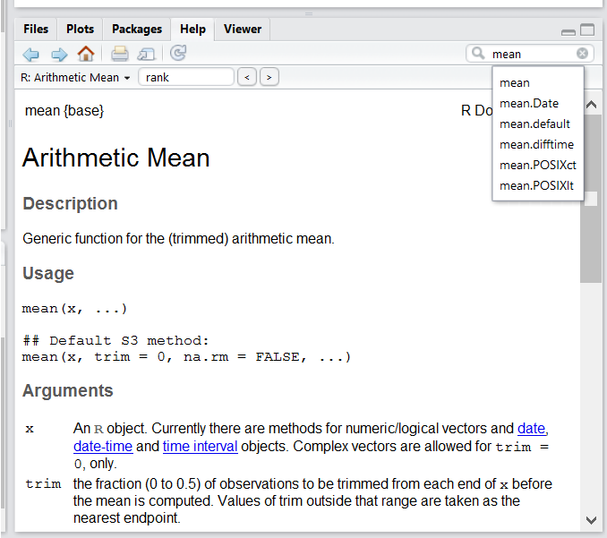

### Automatic code completion

When you write code in RStudio, you can use its automatic code completion to remind yourself of a function’s name or arguments. Start typing the function name and pay attention to the suggestions that pop up. Use the up and down arrow to select a suggested code completion and `Tab` to apply it. You can also use code completion to complete function’s argument names, object, names and file names. It even works if you don’t get the spelling 100% correct.

### Finding more functions and packages

RStudio’s help only searches the packages that you have installed on your machine, but there are many more available on [CRAN](https://cran.r-project.org/) and [GitHub](https://github.com/). To search across all available R packages, you can use the website rdocumentation.org. Often, a generic Google or internet search “R <task>” will send you to the appropriate package documentation or a forum where someone else has already asked your question. Many packages also have websites with additional help, tutorials, news and more (for example [tidyverse.org](https://www.tidyverse.org/)).

### Dealing with error messages

Don’t get discouraged if your code doesn’t run immediately! Error messages are common when programming, and fixing errors is part of any programmer’s daily work. Often, the problem is a small typo in a variable name or a missing parenthesis. Watch for the red x’s next to your code in RStudio. These may provide helpful hints about the source of the problem.

Finding errors is very common for everyone. We will run into errors as we work together today infact. I’ll try to talk through them as we run into them.

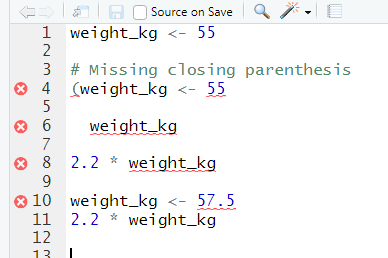

If you can’t fix an error yourself, start by googling it. Some error messages are too generic to diagnose a problem (e.g. “subscript out of bounds”). In that case it might help to include the name of the function or package you’re using in your query.

### Asking for help

If your Google search is unsuccessful, you may want to ask other R users for help. There are different places where you can ask for help. During this workshop, don’t hesitate to talk to your neighbor, compare your answers, and ask for help. You might also be interested in organizing regular meetings following the workshop to keep learning from each other. If you have a friend or colleague with more experience than you, they might also be able and willing to help you.

When it doubt always google! And at some point you may need to post a question on one of the many R communities. The key to receiving help from someone is for them to rapidly grasp your problem. You can read more in extra lesson 07: `07-extra-make-reproducible-examples`

## How to learn more after the workshop?

The material we cover during this workshop will give you a taste of how you can use R to analyze data for your own research. However, to do advanced operations such as cleaning your dataset, using statistical methods, or creating beautiful graphics you will need to learn more.

The best way to become proficient and efficient at R, as with any other tool, is to use it to address your actual research questions. As a beginner, it can feel daunting to have to write a script from scratch, and given that many people make their code available online, modifying existing code to suit your purpose might get first hands-on experience using R for your own work and help you become comfortable eventually creating your own scripts.

## More resources

#### More about R

After this workshop is over you’ll hopefully be ready to tackle learning R fully. Some of you might feel confident enough to start doing a project your self. Others may feel they need a refrsher. Here are some useful next steps depending on how you feel at the end today.

**Useful**

- Go back through these lessons on your R! I would suggest everyone go back through the lessons after we’re done here. Use that time to try things out that you didnt have time during class. Go through the ‘extra’ lessons as well
- Go through a Data or Software Carpentries lesson online:
  - [R for Reproducible Scientific Analysis (Software Carpentry)](https://swcarpentry.github.io/r-novice-gapminder/)
  - [R para Análisis Científicos Reproducibles(Software Carpentry)](https://swcarpentry.github.io/r-novice-gapminder-es/)
  - [Data Analysis and Visualization in R for Ecologists (Data Carpentry)](https://datacarpentry.org/R-ecology-lesson/)
- `Swirl` - R package that is will help walk you through beginner concepts in R. Its actually used **inside** R! Its great for people who feel like they were not able to grab the concepts by the end of class, or just need a refresher. Just install the package in R

```r
install.packages("swirl")
library("swirl")
swirl()
```

- R for Data Science - Next step - intermediate level - learning. This is an ebook written by the same package writer who wrote many of the packages we’re goiong to use today. Its written for some one who really wants to dive into the finer programmer level details of R. Theres many useful tips, tricks, and secrets hiding in this ebook though. I definitely recommend it at some point in your R learning. [R for Data Science](https://r4ds.hadley.nz/)
- Get a project and start playing around with R!

**Dry**

- The [Introduction to R](https://cran.r-project.org/doc/manuals/R-intro.pdf) can be dense for people with little programming experience but it is a good place to understand the underpinnings of the R language.
- The [R FAQ](https://cran.r-project.org/doc/FAQ/R-FAQ.html) is dense and technical but it is full of useful information.
- To stay up to date, follow `#rstats` on twitter. Twitter can also be a way to get questions answered and learn about useful R packages and tipps (e.g., [@RLangTips])
- Coursera - Can be difficult to grasp as someone who hasnt learned a programming language before, however after this course you should be able to handle faster and with a leg up. It’s also a more course centric approach if thats what you need.
- There are an abundance of R centric books out there now, most of them free in ebook form.

[figure not shown]

# Keypoints

- R is a programming language and RStudio is the IDE that assists in using R.
- There are many benefits to learning R, including writing reproducibile code, ability to use a variety of datasets, and a broad, open-source community of practioners.
- Files related to analysis should be organized within a single working directory.
- R uses commands containing functions to tell the computer what to do.
- Documentation for each function is available within RStudio, or users can ask for help from one of many online forums, cheatsheets, or email lists.